# Homework 11 Assigned 10/13/17

**Created by Robin Cunningham, UNC Chapel Hill**

output: html_document

Intro to Multiple Linear Regression

# Amanda LIU

## #730042603

*GPA Data Set*

*We will use this exercise to compare the regression coefficients that we find by solving the Normal Equations (Slide 9 of Lecture 5) to the Output from using `lm` to find the regression coefficients.*

1. Get the data set “College GPA.csv” and put it in your working directory along with this document and the console of R-Studio. Note that all of the code boxes below are set to `eval=FALSE` so that your file will *knit* but you will need to change this to put out your answers.
1. Read in the GPA file and assign it to the handy name provided.Then go ahead and print it so you have it for reference.

   ```r
   gpa <- read.csv("College GPA.csv")
   gpa
   ```

   ```
   ##    First.Yr.GPA Math.SAT Verbal.SAT HS.Math.GPA HS.English.GPA
   ## 1          1.97      321        247        2.30           2.63
   ## 2          2.74      718        436        3.80           3.57
   ## 3          2.19      358        578        2.98           2.57
   ## 4          2.60      403        447        3.58           2.21
   ## 5          2.98      640        563        3.38           3.48
   ## 6          1.65      237        342        1.48           2.14
   ## 7          1.89      270        472        1.67           2.64
   ## 8          2.38      418        356        3.73           2.52
   ## 9          2.66      443        327        3.09           3.20
   ## 10         1.96      359        385        1.54           3.46
   ## 11         3.14      669        664        3.21           3.37
   ## 12         1.96      409        518        2.77           2.60
   ## 13         2.20      582        364        1.47           2.90
   ## 14         3.90      750        632        3.14           3.49
   ## 15         2.02      451        435        1.54           3.20
   ## 16         3.61      645        704        3.50           3.74
   ## 17         3.07      791        341        3.20           2.93
   ## 18         2.63      521        483        3.59           3.32
   ## 19         3.11      594        665        3.42           2.70
   ## 20         3.20      653        606        3.69           3.52
   ```

2. Create each of the Matrices, X, Y, and Beta_hat that you will need to solve the normal equations.
   $$X\hat{B} =Y$$
   Begin by defining variables
   $$Y = First year GPA$$
   $$X1 = Math SAT$$
   $$X2 = Verbal SAT$$
   $$X3 = HS Math GPA$$
   $$X4 = HS English GPA.$$
   Then initialize a Beta_hat vector of all zeros and the appropriate length.

   ```r
   n <- nrow(gpa)
   n
   ```

   ```
   ## [1] 20
   ```

   ```r
   Y<- c(gpa$First.Yr.GPA)
   X1 <- c(gpa$Math.SAT)
   X2 <- c(gpa$Verbal.SAT)
   X3 <- c(gpa$HS.Math.GPA)
   X4 <- c(gpa$HS.English.GPA)
   Beta_hat = numeric(length = 5)
   Beta_hat
   ```

   ```
   ## [1] 0 0 0 0 0
   ```

3. We have our variables now, but they are all stored as vectors and we must convert them to matrices. Use `cbind` to create the matrix X. You will need to create a vector of 1’s of the appropriate length first. Also, use the `matrix` command to turn Y and Beta_hat into matrices with the correct dimensions. After you have made them, go ahead and print (with labels) all three Matrices for the normal equations with labels.

   ```r
   Beta_hatm= matrix(Beta_hat,nrow=5,byrow=TRUE)
   Beta_hatm
   ```

   ```
   ##      [,1]
   ## [1,]    0
   ## [2,]    0
   ## [3,]    0
   ## [4,]    0
   ## [5,]    0
   ```

   ```r
   matrixY = matrix(Y, nrow = n, ncol=1)
   matrixY
   ```

   ```
   ##       [,1]
   ##  [1,] 1.97
   ##  [2,] 2.74
   ##  [3,] 2.19
   ##  [4,] 2.60
   ##  [5,] 2.98
   ##  [6,] 1.65
   ##  [7,] 1.89
   ##  [8,] 2.38
   ##  [9,] 2.66
   ## [10,] 1.96
   ## [11,] 3.14
   ## [12,] 1.96
   ## [13,] 2.20
   ## [14,] 3.90
   ## [15,] 2.02
   ## [16,] 3.61
   ## [17,] 3.07
   ## [18,] 2.63
   ## [19,] 3.11
   ## [20,] 3.20
   ```

   ```r
    X= matrix(1,nrow=n,ncol=5)
    X[,2]=X1
    X[,3]=X2
    X[,4]=X3
    X[,5]=X4
    X
   ```

   ```
   ##       [,1] [,2] [,3] [,4] [,5]
   ##  [1,]    1  321  247 2.30 2.63
   ##  [2,]    1  718  436 3.80 3.57
   ##  [3,]    1  358  578 2.98 2.57
   ##  [4,]    1  403  447 3.58 2.21
   ##  [5,]    1  640  563 3.38 3.48
   ##  [6,]    1  237  342 1.48 2.14
   ##  [7,]    1  270  472 1.67 2.64
   ##  [8,]    1  418  356 3.73 2.52
   ##  [9,]    1  443  327 3.09 3.20
   ## [10,]    1  359  385 1.54 3.46
   ## [11,]    1  669  664 3.21 3.37
   ## [12,]    1  409  518 2.77 2.60
   ## [13,]    1  582  364 1.47 2.90
   ## [14,]    1  750  632 3.14 3.49
   ## [15,]    1  451  435 1.54 3.20
   ## [16,]    1  645  704 3.50 3.74
   ## [17,]    1  791  341 3.20 2.93
   ## [18,]    1  521  483 3.59 3.32
   ## [19,]    1  594  665 3.42 2.70
   ## [20,]    1  653  606 3.69 3.52
   ```

c. Calculate the least squares values of Beta_hat. In the calculation of the least squares values, I recommend calculating X^tX first, then the inverse, then Beta_hat.  
I went ahead and wrote the code to print out the Beta_i values after they are calculated.

```r
X_TRANSX = t(X)%*%X
Inverse = solve(X_TRANSX)
Beta_hat = Inverse%*%t(X)%*%Y
Beta_hat

labels = matrix(c("Beta_0", "Beta_1", "Beta_2", "Beta_3", "Beta_4"), nrow = 5)
beta_summary <- cbind(labels, Beta_hat)
beta_summary
```

[output not shown]

4. Now that you know how `lm` calculates these coefficients, it is ok to use `lm` directly to calculate the least-squares statistics. Do that here and assign the model to the name gpa.mlr. Then get the summary output of the model.

   ```r
   gpa.mlr=lm(Y~X1+X2+X3+X4,data=gpa)
   summary(gpa.mlr)
   ```

   ```
   ##
   ## Call:
   ## lm(formula = Y ~ X1 + X2 + X3 + X4, data = gpa)
   ##
   ## Residuals:
   ##      Min       1Q   Median       3Q      Max
   ## -0.44328 -0.12837  0.00257  0.13400  0.53900
   ##
   ## Coefficients:
   ##              Estimate Std. Error t value Pr(>|t|)
   ## (Intercept) 0.1615496  0.4375321   0.369  0.71712
   ## X1          0.0020102  0.0005844   3.439  0.00365 **
   ## X2          0.0012522  0.0005515   2.270  0.03835 *
   ## X3          0.1894402  0.0918680   2.062  0.05697 .
   ## X4          0.0875637  0.1764963   0.496  0.62700
   ## ---
   ## Signif. codes:  0 '***' 0.001 '**' 0.01 '*' 0.05 '.' 0.1 ' ' 1
   ##
   ## Residual standard error: 0.2685 on 15 degrees of freedom
   ## Multiple R-squared:  0.8528, Adjusted R-squared:  0.8135
   ## F-statistic: 21.72 on 4 and 15 DF,  p-value: 4.255e-06
   ```

5. How do your estimates of the parameters compare to R’s?(Comment box below)

```
They are the same.
```

6. Interpret each of the regression paramaters in words. That is, explain what each value means in terms of the scenario. ``` beta1<-When the other scores remains the same, each unit of increase OR decrease in MATH SAT score will result in a student’s college GPA estimates to be increase OR decrease 0.0020102.

beta2<-When the other scores remains the same, each unit of increase OR decrease in Verbal SAT score will result in a student’s college GPA estimates to be increase OR decrease 0.0012522.

beta3<-When the other scores remains the same, each unit of increase OR decrease in high school Math GPA will result in a student’s college GPA estimates to be increase OR decrease 0.1894402.

beta4<-When the other scores remains the same, each unit of increase OR decrease in high school Verbal GPA will result in a student’s college GPA estimates to be increase OR decrease 0.0875637.

beta0<-When a student has scored 0 on all of the SAT Math, SAT Verbal, High Schhol Math GPA, High School Verbal GPA, he would then have a estimate college GPA of 0.1615496. ``` g. Find a 95% confidence interval for $\beta_4$.(Use either a code-box, a comment box, or both to hold your answer.)

```r
df= 15
t=qt(0.975,df)

se=0.1764963
pe=0.0875637
upper=pe+se*t
upper
```

```
## [1] 0.4637567
```

```r
lower=pe-se*t
lower
```

```
## [1] -0.2886293
```

```
The 95% confidence interval for beta4 is (-0.2886293,0.4637567).
```

8. For a new individual with  
   MSAT = 640  
   VSAT = 540  
   HSM = 3.8  
   HSE = 3.2  
   What is your best estimate for their 1st-year gpa?  
   Please use R to give your answer.

```r
GPA=640*0.0020102+540*0.0012522+3.8*0.1894402+3.2*0.0875637+0.1615496
GPA
```

```
## [1] 3.124342
```

1. For the person described in Part (h), find a 95% confidence interval for their 1st-year gpa. (Note that s^2 is given in the R output of the linear model.)

```r
df= 15
t=qt(0.975,df)

s=0.2685
x=matrix(c(1,640,540,3.8,3.2),byrow = TRUE)
C=solve(t(X)%*%X)
se= s*sqrt(t(x)%*%C%*%x)
upper=GPA+se*t
upper
```

```
##          [,1]
## [1,] 3.319964
```

```r
lower=GPA-se*t
lower
```

```
##         [,1]
## [1,] 2.92872
```

```
The 95% confidence interval for the 1st-year GPA of the person is (2.92872,3.319964).
```

10. We should have done this to start the regression analysis, but make plots of Y versus each of the predictors (4 plots) and discuss what you see. (Try to get everything into this RMarkdown document. No paper this time.)

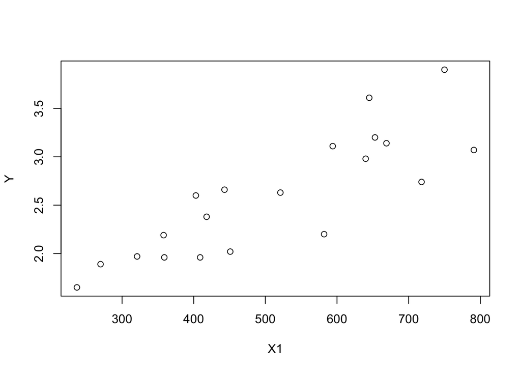

```r
plot(X1,Y)
```

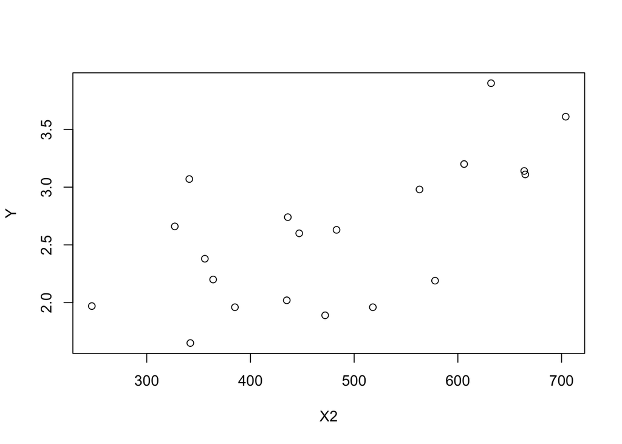

```r
plot(X2,Y)
```

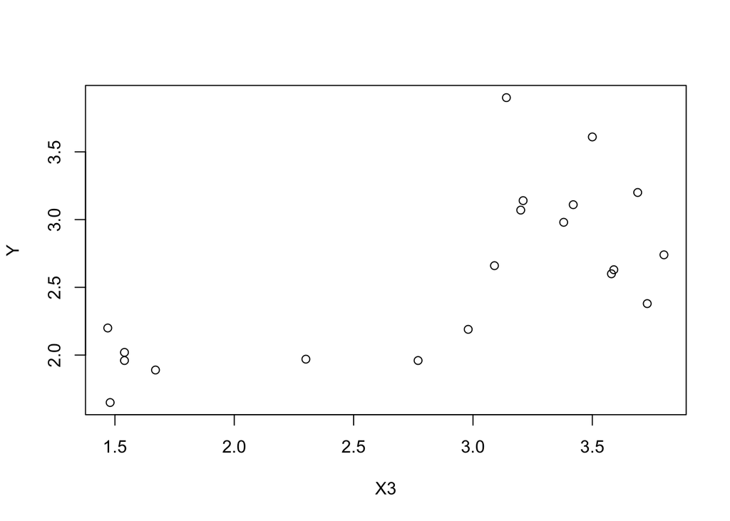

```r
plot(X3,Y)
```

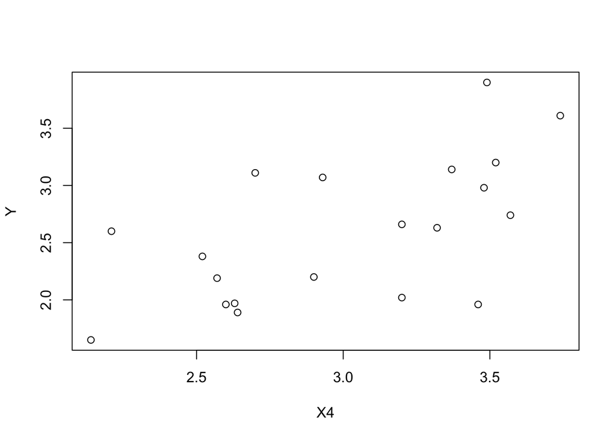

```
1) Y increasing with the increase of X1, which is good.
2) Y roughly increase with the increase of X2, which is good.
3) Y roughly increase with the increase of X3. The data was mainly gathered at score higher than 3.0.  This would affect the regression model.
4) It is hard to see a relationship between two parameter. X4 might be a less effective predictors.
```

```r
plot(X4,Y)
```

11. Makes histograms of each of the variables to see if there are any obvious outliers or other odd behavior. Print the histograms and any comments.

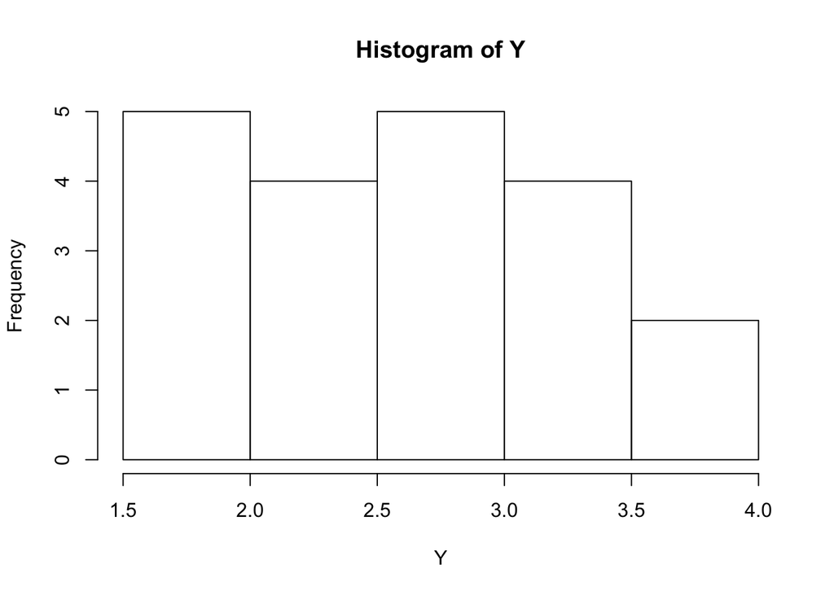

```r
hist(Y)
```

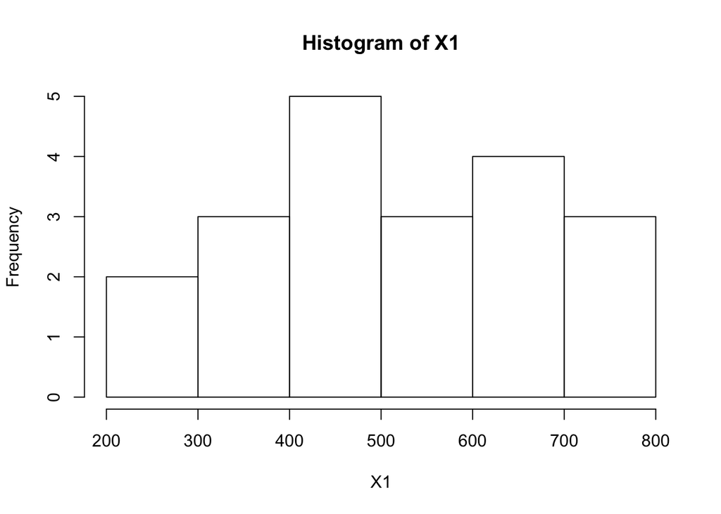

```r
hist(X1)
```

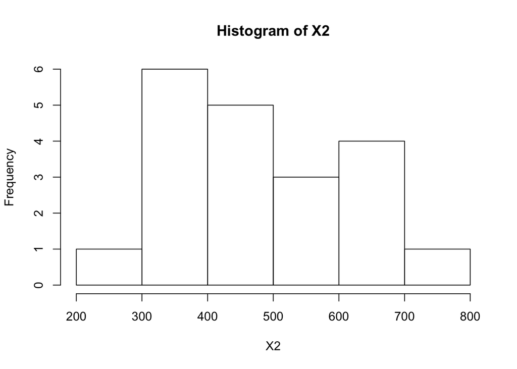

```r
hist(X2)
```

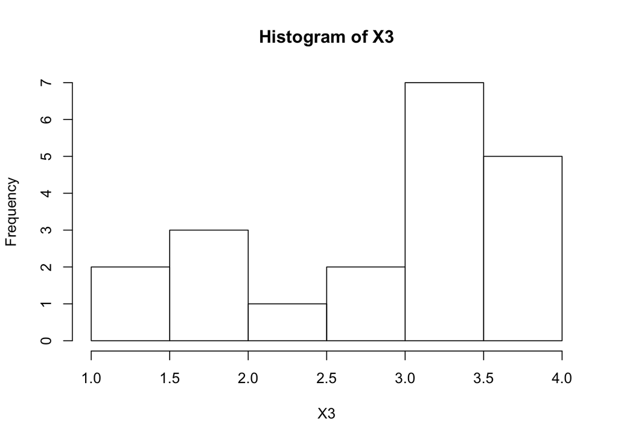

```r
hist(X3)
```

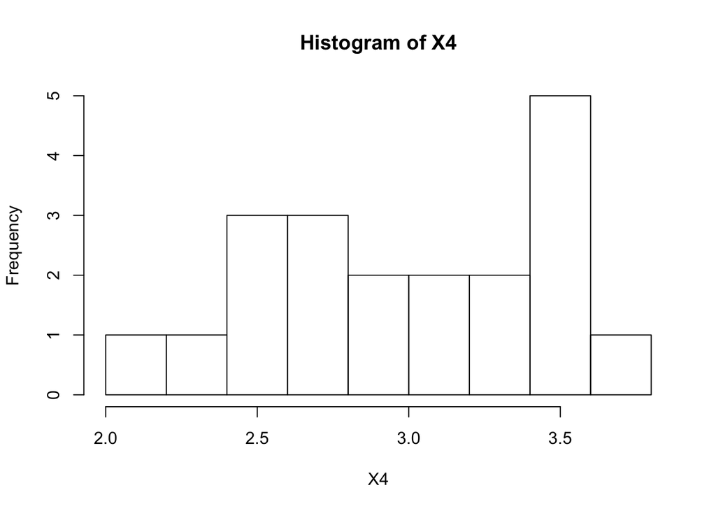

```
1)The data of first year gpa is evenly spread at each range. Nothing strange.
2)The data of MATH SAT score is roughly evenly spread at each range.
3)There are not much data of SAT verbal score at the range (200,300) and (700.,800), which will affect the regression model.
4)There are not much students scored lower than 3.0 at high school MATH gpa.
5)This is strange because there are a lot of students scored around 3.5 on high school verbal GPA, which might become an outlier phenomenon that affect the model.
```

```r
hist(X4)
```

12. Plot residuals versus fitted values (Y-hat_i) and the QQ plot of residuals. It is ok to use `lm` for this. Include any comments on what these diagnostic plots indicate.

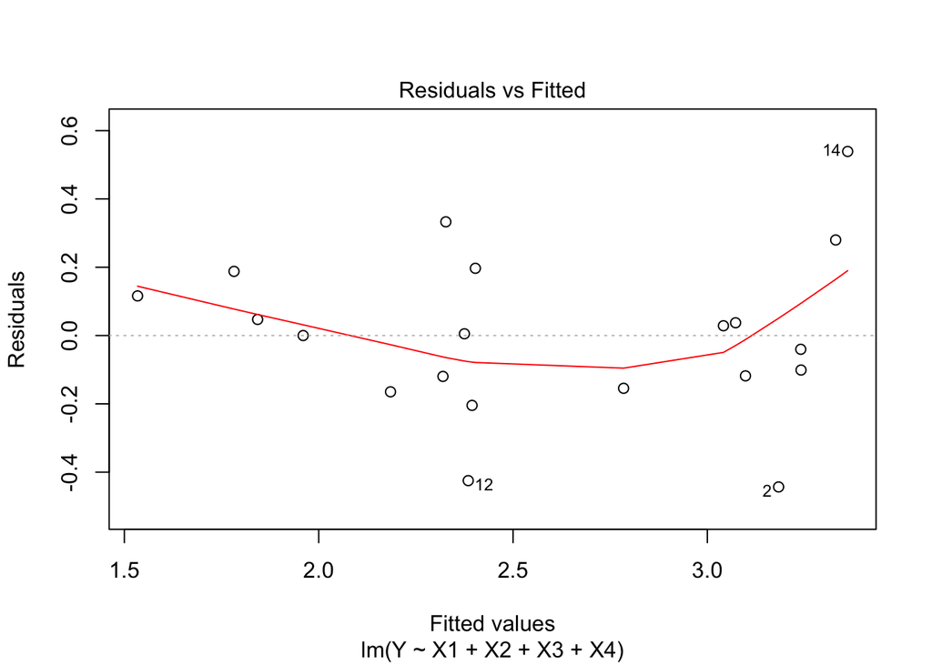

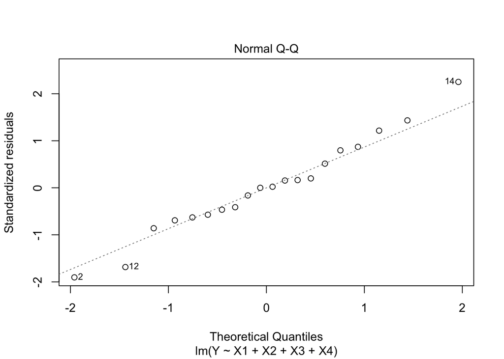

```
1)Residuals vs fitted values: The data's residuals are roughly spread evenly among y=0. But we can see that data 12 and 2 include some outliers influencing the overall model.
2)QQ plot: The reisduals are almost normally distributed, but there are a few outliers:data 2, 12, and 14.
```

```r
plot(gpa.mlr,which=1:2)
```

13. Find a 95% prediction interval for the individual described in Part (h) above. It is ok to use R’s `predict` function for this. Interpret the result in terms of the scenario.

```r
student=data.frame(X1=640,X2=540,X3=3.8,X4=3.2)
predict(gpa.mlr,student,interval="predict")
```

```
##       fit      lwr      upr
## 1 3.12432 2.519483 3.729157
```

[output not shown]